# **Spam Detection HW**

**Read complete instructions before starting the HW**

# **Q1: Load the dataset (1 Point)**

- For this Hw you will usespam dataset from kaggle which can be found from [this](https://www.kaggle.com/uciml/sms-spam-collection-dataset) link. You can download this data and either upload it in google drive or in colab workspace. Load the data in pandas dataframe.
- There are only two useful columns. These columns are related to (1) label (ham and spam) and the (2) text of email.
- Rename columns as label and message
- Find the % ham amd spam in the data.

```python
import sys
if 'google.colab' in str(get_ipython()):
    from google.colab import files

    uploaded = files.upload()

    for fn in uploaded.keys():
      print('User uploaded file "{name}" with length {length} bytes'.format(
        name=fn, length=len(uploaded[fn])))

# Then move kaggle.json into the folder where the API expects to find it.

    !mkdir -p ~/.kaggle/ && mv kaggle.json ~/.kaggle/ && chmod 600 ~/.kaggle/kaggle.json
    !kaggle datasets download "uciml/sms-spam-collection-dataset"
    !unzip sms-spam-collection-dataset.zip
```

```python
import pandas as pd
if 'google.colab' in str(get_ipython()):
    spam_df = pd.read_csv('spam.csv', encoding='latin-1')
else:
    spam_df = pd.read_csv('/Users/harikrishnadev/Library/CloudStorage/GoogleDrive-harikrish0607@gmail.com/My Drive/Colab_Notebooks/BUAN_6342_Applied_Natural_Language_Processing/0_Data_Folder/spam.csv', encoding='latin-1')
spam_df = spam_df[['v1','v2']]
spam_df.columns = ['label', 'message']
spam_df.head()
```

|  | label | message |
| --- | --- | --- |
| 0 | ham | Go until jurong point, crazy.. Available only ... |
| 1 | ham | Ok lar... Joking wif u oni... |
| 2 | spam | Free entry in 2 a wkly comp to win FA Cup fina... |
| 3 | ham | U dun say so early hor... U c already then say... |
| 4 | ham | Nah I don't think he goes to usf, he lives aro... |

```python
spam_df['label'].value_counts()
```

```
label
ham     4825
spam     747
Name: count, dtype: int64
```

```python
spam_df['label'].value_counts(normalize=True)*100
```

```
label
ham     86.593683
spam    13.406317
Name: proportion, dtype: float64
```

```python
spam_df['label'].replace({'ham':0, 'spam':1}, inplace=True)
```

```python
spam_df['label'].value_counts(normalize=True)*100
```

```
label
0    86.593683
1    13.406317
Name: proportion, dtype: float64
```

# **Q2 : Provide the metric for evaluating model (1 Point)**

As you will notice, the data is highly imbalanced (most messages are labelled as ham and only few are labelled as spam). Always predicting ham will give us very good accuracy (close to 90%). So you need to choose a different metric.

Task: Provde the metric you will choose to evaluate your model. Explain why this is an appropriate metric for this case.

Using F1 Score for the minority class would help us. As it provides balance between Precision and recall. In this experiment, my trial with using recall led to decline in accuracy.

# **Q3 : Classification Pipelines (18 Points)**

In the previous lectures you learned Data processing, Featurization such as CountVectorizer, TFIDFVectorizer, and also Feature Engineering.

- You will now use folllowing methods to create fearures which you can use in your model.
  1. Sparse Embeddings (TF-IDF) (6 Points)
  2. Feature Engineering (see examples below) (6 Points)
  3. Sparse Embeddings (TF-IDF) + Feature Engineering (6 Points)

**Approach:**

****Use a smaller subset of dataset (e.g. 5-10 %) to evaluate the three pipelines . Based on your analysis (e.g. model score, learning curves) , choose one pipeline from the three. Provde your rational for choosing the pipleine. Train only the final pipeline on randomly selected larger subset (e.g. 40%) of the data.**

**Requirements:**

1. You can use any ML model (Logistic Regression, XgBoost) for the classification. You will need to tune the **model for imbalanced dataset** (The link on XGBoost tutorial for imbalanced data: https://machinelearningmastery.com/xgboost-for-imbalanced-classification/).
2. For feature engineering, you can choose from the examples below. You do not have to use all of them. You can add other featues as well. Think about what faetures can distinguish a spam from a regular email. Some examples :

> > Count of following (Words, characters, digits, exclamation marks, numbers, Nouns, ProperNouns, AUX, VERBS, Adjectives, named entities, spelling mistakes (see the link on how to get spelling mistakes https://pypi.org/project/pyspellchecker/).
3. For Sparse embeddings you will use **tfidf vectorization**. You need to choose appopriate parameters e.g. min_df, max_df, max_faetures, n-grams etc.).
4. Think carefully about the pre-processing you will do.

Tip: **Using GridSearch for hyperparameter tuning might take a lot of time. Try using RandomizedSearch.** You can also explore faster implementation of Gridsearch and RandomizedSearch in sklearn:

1. [Halving Grid Search](https://scikit-learn.org/stable/modules/generated/sklearn.model_selection.HalvingGridSearchCV.html?highlight=halving#sklearn.model_selection.HalvingGridSearchCV)
2. HalvingRandomSearchCV

# **Required Submissions:**

1. Submit two colab/jupyter notebooks
- (analysis with smaller subset and all three pipelines)
- (analysis with bigger subset and only final pipeline)
2. Pdf version of the notebooks (HWs will not be graded if pdf version is not provided.
3. **The notebooks and pdf files should have the output.**
4. **Name files as follows : FirstName_file1_hw2, FirstName_file2_h2**

```python
spam_df_small = spam_df.sample(frac=0.05).reset_index(drop=True)
spam_df_small.head()
```

|  | label | message |
| --- | --- | --- |
| 0 | 0 | Good afternoon, my love. How goes your day ? W... |
| 1 | 0 | There's no point hangin on to mr not right if ... |
| 2 | 1 | u r subscribed 2 TEXTCOMP 250 wkly comp. 1st w... |
| 3 | 0 | I though we shd go out n have some fun so bar ... |
| 4 | 0 | I thk 50 shd be ok he said plus minus 10.. Did... |

```python
spam_df_small['label'].value_counts(normalize=True)*100
```

```
label
0    87.81362
1    12.18638
Name: proportion, dtype: float64
```

```python
import sklearn
from sklearn.model_selection import train_test_split
X = spam_df_small['message'].values
y = spam_df_small['label'].values

X_train, X_test, y_train, y_test = train_test_split(X, y, test_size=0.2,stratify=y,shuffle=True)
print(X_train[:5])
print(y_train[:5])
print(X_test[:5])
print(y_test[:5])
```

```
['\\HELLO U.CALL WEN U FINISH WRK.I FANCY MEETIN UP WIV U ALL TONITE AS I NEED A BREAK FROM DABOOKS. DID 4 HRS LAST NITE+2 TODAY OF WRK!\\""'
 'Abeg, make profit. But its a start. Are you using it to get sponsors for the next event?'
 'I sent them. Do you like?'
 'Your free ringtone is waiting to be collected. Simply text the password \\MIX\\" to 85069 to verify. Get Usher and Britney. FML'
 'Play w computer? Aiyah i tok 2 u lor?']
[0 0 0 1 0]
['No b4 Thursday'
 'So many people seems to be special at first sight, But only very few will remain special to you till your last sight.. Maintain them till life ends.. Sh!jas'
 "Like I made him throw up when we were smoking in our friend's car one time, it was awesome"
 'Mmm thats better now i got a roast down me! iåÕd b better if i had a few drinks down me 2! Good indian?'
 'HI DARLIN IM MISSIN U HOPE YOU ARE HAVING A GOOD TIME. WHEN ARE U BACK AND WHAT TIME IF U CAN GIVE ME A CALL AT HOME. JESS XX']
[0 0 0 0 0]
```

```python
import sys
if 'google.colab' in str(get_ipython()):
    from google.colab import drive
    drive.mount('/content/drive')

    !pip install -U nltk -qq
    !pip install -U spacy -qq
    !pip install -U scikit-optimize -qq
    !python -m spacy download en_core_web_sm -qq
    !pip install pyspellchecker -qq
    !pip install optuna -qq

    basepath = '/content/drive/MyDrive/Colab_Notebooks/BUAN_6342_Applied_Natural_Language_Processing'
    sys.path.append('/content/drive/MyDrive/Colab_Notebooks/BUAN_6342_Applied_Natural_Language_Processing/0_Custom_files')
else:
    basepath = '/Users/harikrishnadev/Library/CloudStorage/GoogleDrive-harikrish0607@gmail.com/My Drive/Colab_Notebooks/BUAN_6342_Applied_Natural_Language_Processing/'
    sys.path.append(
        '/Users/harikrishnadev/Library/CloudStorage/GoogleDrive-harikrish0607@gmail.com/My Drive/Colab_Notebooks/BUAN_6342_Applied_Natural_Language_Processing/0_Custom_files')
```

```python
from pathlib import Path
base_folder = Path(basepath)
data_folder = base_folder/'0_Data_Folder'
model_folder = base_folder/'models/spam'
custom_functions = base_folder/'custom-functions'
```

```python
import CustomPreprocessorSpacy as cp
from FeaturizerSpacy_w_SpellChecker import ManualFeatures
from plot_learning_curve import plot_learning_curve
```

```python
import spacy
nlp = spacy.load('en_core_web_sm')
```

```python
cpp = cp.SpacyPreprocessor(model = 'en_core_web_sm', batch_size=500)
```

```python
X_train_cleaned_bow = cpp.transform(X_train)
X_test_cleaned_bow = cpp.transform(X_test)
```

```
/Users/harikrishnadev/Library/CloudStorage/GoogleDrive-harikrish0607@gmail.com/My Drive/Colab_Notebooks/BUAN_6342_Applied_Natural_Language_Processing/0_Custom_files/CustomPreprocessorSpacy.py:83: MarkupResemblesLocatorWarning: The input looks more like a filename than markup. You may want to open th…
  soup = BeautifulSoup(text, "html.parser")
```

```python
# Import the joblib library for saving and loading models
import joblib
import os

file_X_train_cleaned_bow = data_folder / 'x_train_cleaned_bow_small.pkl'
os.makedirs(os.path.dirname(file_X_train_cleaned_bow), exist_ok=True)
joblib.dump(X_train_cleaned_bow, file_X_train_cleaned_bow)

file_X_test_cleaned_bow = data_folder / 'x_test_cleaned_bow_small.pkl'
os.makedirs(os.path.dirname(file_X_test_cleaned_bow), exist_ok=True)
joblib.dump(X_test_cleaned_bow, file_X_test_cleaned_bow)
```

```
['/Users/harikrishnadev/Library/CloudStorage/GoogleDrive-harikrish0607@gmail.com/My Drive/Colab_Notebooks/BUAN_6342_Applied_Natural_Language_Processing/0_Data_Folder/x_test_cleaned_bow_small.pkl']
```

```python
import numpy as np
unique, counts = np.unique(y_train,return_counts=True)
print(dict(zip(unique, counts/sum(counts))))
```

```
{0: 0.8789237668161435, 1: 0.1210762331838565}
```

```python
weights = dict(zip(unique[::-1], counts/sum(counts)))
weights
```

```
{1: 0.8789237668161435, 0: 0.1210762331838565}
```

# Sparse Embeddings

```python
import optuna
from sklearn.model_selection import cross_val_score
from sklearn.feature_extraction.text import TfidfVectorizer
from sklearn.linear_model import LogisticRegression
from sklearn.pipeline import Pipeline
from sklearn.metrics import make_scorer, f1_score, recall_score, precision_score

def objective(trial):
    # Define the hyperparameters to search over
    max_features = trial.suggest_int('max_features', 100, 10000)
    C = trial.suggest_loguniform('C', 1e-5, 100)
    weight = trial.suggest_float('weight', 0.1, 0.9)

    class_weight = {0: 1 - weight, 1: weight}

    # Create a pipeline with the current set of hyperparameters
    classifier_1 = Pipeline([
        ('vectorizer', TfidfVectorizer(analyzer='word', token_pattern=r"[\S]+", max_features=max_features)),
        ('classifier', LogisticRegression(max_iter=10000, C=C, class_weight=class_weight))
    ])

    # Use cross-validation to evaluate the classifier with the current hyperparameters
    # Use f1_score as the scoring metric
    scores = cross_val_score(classifier_1, X_train, y_train, cv=5, scoring=make_scorer(f1_score, pos_label=1))
    return scores.mean()
```

```python
study = optuna.create_study(direction='maximize')
study.optimize(objective, n_trials=100)
```

[output not shown]

[output cut: 75 more lines]

```python
# Get the best hyperparameters found by Optuna
best_max_features = study.best_params['max_features']
best_C = study.best_params['C']
best_weight = study.best_params['weight']
```

```python
study.best_params
```

```
{'max_features': 5865, 'C': 4.08525761456645, 'weight': 0.8735645566660062}
```

```python
study.best_value
```

```
0.8969696969696969
```

```python
best_classifier_1 = Pipeline([
    ('vectorizer', TfidfVectorizer(analyzer='word', token_pattern=r"[\S]+", max_features=best_max_features)),
    ('classifier', LogisticRegression(max_iter=10000, C=best_C,class_weight={0: 1 - best_weight, 1: best_weight}))
])
```

```python
best_classifier_1.fit(X_train_cleaned_bow, y_train)
```

```
Pipeline(steps=[('vectorizer',
                 TfidfVectorizer(max_features=5865, token_pattern='[\\S]+')),
                ('classifier',
                 LogisticRegression(C=4.08525761456645,
                                    class_weight={0: 0.1264354433339938,
                                                  1: 0.8735645566660062},
                                    max_iter=10000))])
```

```python
print(f'Best cross-validation score: {study.best_value:.2f}')
print("\nBest parameters: ", study.best_params)
print("\nBest estimator: ", best_classifier_1)
```

```
Best cross-validation score: 0.90

Best parameters:  {'max_features': 5865, 'C': 4.08525761456645, 'weight': 0.8735645566660062}

Best estimator:  Pipeline(steps=[('vectorizer',
                 TfidfVectorizer(max_features=5865, token_pattern='[\\S]+')),
                ('classifier',
                 LogisticRegression(C=4.08525761456645,
                                    class_weight={0: 0.1264354433339938,
                                                  1: 0.8735645566660062},
                                    max_iter=10000))])
```

```python
study.__dict__
```

```
{'study_name': 'no-name-5a16edf9-5b7b-455e-b4e3-161d7d7b954f',
 '_study_id': 0,
 '_storage': <optuna.storages._in_memory.InMemoryStorage at 0x2a15a54d0>,
 '_directions': [<StudyDirection.MAXIMIZE: 2>],
 'sampler': <optuna.samplers._tpe.sampler.TPESampler at 0x2a00033d0>,
 'pruner': <optuna.pruners._median.MedianPruner at 0x2a155ec50>,
 '_thread_local': <optuna.study.study._ThreadLocalStudyAttribute at 0x2a17526f0>,
 '_stop_flag': False}
```

```
<module 'matplotlib.pyplot' from '/opt/homebrew/anaconda3/envs/nlp/lib/python3.11/site-packages/matplotlib/pyplot.py'>
```

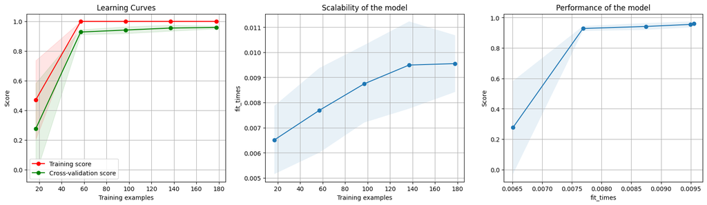

```python
plot_learning_curve(best_classifier_1, 'Learning Curves',
                    X_train_cleaned_bow, y_train, n_jobs=-1)
```

```python
def final_pipeline(pipeline,cleaned_text):
    predictions = pipeline.predict(cleaned_text)
    return predictions
y_test_pred = final_pipeline(best_classifier_1,X_test_cleaned_bow)
```

```python
import sklearn.metrics as metrics
print('\nTest set classification report:\n\n',
      metrics.classification_report(y_test, y_test_pred))
```

```
Test set classification report:

               precision    recall  f1-score   support

           0       0.96      1.00      0.98        49
           1       1.00      0.71      0.83         7

    accuracy                           0.96        56
   macro avg       0.98      0.86      0.91        56
weighted avg       0.97      0.96      0.96        56
```

# Feature Engineering

```python
X_train_cleaned_basic = cp.SpacyPreprocessor(model='en_core_web_sm',
                                                    lemmatize=False, lower=False,
                                                    remove_stop=False, remove_punct=False,
                                                    remove_email=False, remove_url=False,
                                                     add_user_mention_prefix=False,
                                                     basic_clean_only=True).transform(X_train)
```

```
/Users/harikrishnadev/Library/CloudStorage/GoogleDrive-harikrish0607@gmail.com/My Drive/Colab_Notebooks/BUAN_6342_Applied_Natural_Language_Processing/0_Custom_files/CustomPreprocessorSpacy.py:83: MarkupResemblesLocatorWarning: The input looks more like a filename than markup. You may want to open th…
  soup = BeautifulSoup(text, "html.parser")
```

```python
# save  this to a file
file_X_train_cleaned_basic = data_folder / 'x_train_cleaned_basic_small.pkl'
joblib.dump(X_train_cleaned_basic, file_X_train_cleaned_basic)
```

```
['/Users/harikrishnadev/Library/CloudStorage/GoogleDrive-harikrish0607@gmail.com/My Drive/Colab_Notebooks/BUAN_6342_Applied_Natural_Language_Processing/0_Data_Folder/x_train_cleaned_basic_small.pkl']
```

```python
X_test_cleaned_basic = cp.SpacyPreprocessor(model='en_core_web_sm',
                                                    lemmatize=False, lower=False,
                                                    remove_stop=False, remove_punct=False,
                                                    remove_email=False, remove_url=False,
                                                     add_user_mention_prefix=False,
                                                     basic_clean_only=True).transform(X_test)
file_X_test_cleaned_basic = data_folder / 'x_test_cleaned_basic_small.pkl'
joblib.dump(X_test_cleaned_basic, file_X_test_cleaned_basic)
```

```
['/Users/harikrishnadev/Library/CloudStorage/GoogleDrive-harikrish0607@gmail.com/My Drive/Colab_Notebooks/BUAN_6342_Applied_Natural_Language_Processing/0_Data_Folder/x_test_cleaned_basic_small.pkl']
```

```python
featurizer = ManualFeatures(spacy_model='en_core_web_sm', batch_size = 1000)
```

```python
ManualFeatures??
```

[output not shown]

[output cut: 164 more lines]

[output not shown]

```python
X_train_features, feature_names = featurizer.fit_transform(X_train_cleaned_basic)
```

```python
X_train_features[0:3]
```

```
array([[ 28.        , 136.        , 109.        ,   3.75862069,
          1.        ,   2.        ,  12.        ,   0.        ,
          3.        ,   2.        ,   1.        ,   0.        ],
       [ 18.        ,  88.        ,  71.        ,   3.73684211,
          0.        ,   3.        ,   4.        ,   1.        ,
          3.        ,   1.        ,   0.        ,   0.        ],
       [  6.        ,  25.        ,  20.        ,   2.85714286,
          0.        ,   2.        ,   0.        ,   1.        ,
          2.        ,   0.        ,   0.        ,   0.        ]])
```

```python
feature_names
```

```
['count_words',
 'count_characters',
 'count_characters_no_space',
 'avg_word_length',
 'count_numbers',
 'count_sentences',
 'spelling_errors',
 'noun_count',
 'aux_count',
 'verb_count',
 'adj_count',
 'ner']
```

```python
classifier_2 = Pipeline([
    ('classifier', LogisticRegression(max_iter=10000)),
])
```

```python
import optuna
from sklearn.model_selection import cross_val_score
from sklearn.feature_extraction.text import TfidfVectorizer
from sklearn.linear_model import LogisticRegression
from sklearn.pipeline import Pipeline
from sklearn.metrics import make_scorer, f1_score, recall_score, precision_score

def objective(trial):
    # Define the hyperparameters to search over
    C = trial.suggest_loguniform('C', 1e-5, 100)
    weight = trial.suggest_float('weight', 0.1, 0.9)

    class_weight = {0: 1 - weight, 1: weight}

    # Create a pipeline with the current set of hyperparameters
    classifier_1 = Pipeline([
        ('classifier', LogisticRegression(max_iter=10000, C=C, class_weight=class_weight))
    ])

    # Use cross-validation to evaluate the classifier with the current hyperparameters
    # Use f1_score as the scoring metric
    scores = cross_val_score(classifier_1, X_train_features, y_train, cv=5, scoring=make_scorer(f1_score, pos_label=1))
    return scores.mean()
```

```python
study = optuna.create_study(direction='maximize')
study.optimize(objective, n_trials=100)
```

[output not shown]

[output cut: 75 more lines]

```python
# Get the best hyperparameters found by Optuna
best_C = study.best_params['C']
best_weight = study.best_params['weight']
```

```python
study.best_params
```

```
{'C': 0.22823093369924694, 'weight': 0.898850258395965}
```

```python
study.best_value
```

```
0.8015567765567766
```

```python
best_classifier_2 = Pipeline([
    ('classifier', LogisticRegression(max_iter=10000, C=best_C,class_weight={0: 1 - best_weight, 1: best_weight}))
])
```

```python
best_classifier_2.fit(X_train_features, y_train)
```

```
Pipeline(steps=[('classifier',
                 LogisticRegression(C=0.22823093369924694,
                                    class_weight={0: 0.101149741604035,
                                                  1: 0.898850258395965},
                                    max_iter=10000))])
```

```
<module 'matplotlib.pyplot' from '/opt/homebrew/anaconda3/envs/nlp/lib/python3.11/site-packages/matplotlib/pyplot.py'>
```

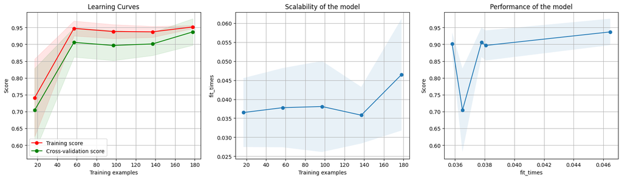

```python
plot_learning_curve(best_classifier_2, 'Learning Curves',
                    X_train_features, y_train, n_jobs=-1)
```

```python
def final_pipeline(pipeline,text):
    features, feature_names = featurizer.fit_transform(text)
    predictions = pipeline.predict(features)
    return predictions
y_test_pred = final_pipeline(best_classifier_2,X_test)
```

```python
import sklearn.metrics as metrics
print('\nTest set classification report:\n\n',
      metrics.classification_report(y_test, y_test_pred))
```

```
Test set classification report:

               precision    recall  f1-score   support

           0       1.00      0.96      0.98        49
           1       0.78      1.00      0.88         7

    accuracy                           0.96        56
   macro avg       0.89      0.98      0.93        56
weighted avg       0.97      0.96      0.97        56
```

```python
X_train_features
```

```
array([[ 28., 136., 109., ...,   2.,   1.,   0.],
       [ 18.,  88.,  71., ...,   1.,   0.,   0.],
       [  6.,  25.,  20., ...,   0.,   0.,   0.],
       ...,
       [  6.,  28.,  23., ...,   0.,   0.,   0.],
       [ 29., 135., 110., ...,   1.,   1.,   0.],
       [  6.,  40.,  35., ...,   1.,   0.,   0.]])
```

```python
X_train_cleaned_bow[:3]
```

```
['\\hello u.call wen u finish wrk.i fancy meetin wiv u tonite need break dabooks 4 hrs nite+2 today wrk!\\',
 'abeg profit start sponsor event',
 'send like']
```

```python
feature_names
```

```
['count_words',
 'count_characters',
 'count_characters_no_space',
 'avg_word_length',
 'count_numbers',
 'count_sentences',
 'spelling_errors',
 'noun_count',
 'aux_count',
 'verb_count',
 'adj_count',
 'ner']
```

```python
X_train_features.shape
```

```
(223, 12)
```

```python
X_train_final = pd.concat((pd.DataFrame(X_train_cleaned_bow, columns=['cleaned_text']),
                           pd.DataFrame(X_train_features, columns=feature_names)), axis=1)
```

```python
X_train_final.head()
```

|  | cleaned_text | count_words | count_characters | count_characters_no_space | avg_word_length | count_numbers | count_sentences | spelling_errors | noun_count | aux_count | verb_count | adj_count | ner |
| --- | --- | --- | --- | --- | --- | --- | --- | --- | --- | --- | --- | --- | --- |
| 0 | \hello u.call wen u finish wrk.i fancy meetin ... | 28.0 | 136.0 | 109.0 | 3.758621 | 1.0 | 2.0 | 12.0 | 0.0 | 3.0 | 2.0 | 1.0 | 0.0 |
| 1 | abeg profit start sponsor event | 18.0 | 88.0 | 71.0 | 3.736842 | 0.0 | 3.0 | 4.0 | 1.0 | 3.0 | 1.0 | 0.0 | 0.0 |
| 2 | send like | 6.0 | 25.0 | 20.0 | 2.857143 | 0.0 | 2.0 | 0.0 | 1.0 | 2.0 | 0.0 | 0.0 | 0.0 |
| 3 | free ringtone wait collect simply text passwor... | 22.0 | 125.0 | 104.0 | 4.521739 | 1.0 | 4.0 | 5.0 | 2.0 | 5.0 | 2.0 | 3.0 | 0.0 |
| 4 | play w computer aiyah tok 2 u lor | 9.0 | 37.0 | 29.0 | 2.900000 | 1.0 | 2.0 | 5.0 | 0.0 | 2.0 | 0.0 | 1.0 | 0.0 |

# Sparse Embeddings (TF-IDF) + Feature Engineering

```python
from sklearn.base import TransformerMixin, BaseEstimator
from scipy.sparse import csr_matrix
class SparseTransformer(TransformerMixin, BaseEstimator):
    def __init__(self):
        pass

    def fit(self, X, y=None):
        return self

    def transform(self, X, y=None):
        return csr_matrix(X)
```

```python
sparse_features = Pipeline([('sparse', SparseTransformer()), ])
vectorizer = Pipeline([('tfidf', TfidfVectorizer(max_features=5)), ])
```

```python
from sklearn.compose import ColumnTransformer
combined_features = ColumnTransformer(
    transformers=[
        ('tfidf', vectorizer, 'cleaned_text'),
    ], remainder=sparse_features
)
```

```python
test = combined_features.fit_transform(X_train_final[0:10])
```

```python
test[:5]
```

```
array([[  0.        ,   0.        ,   0.        ,   0.        ,
          1.        ,  28.        , 136.        , 109.        ,
          3.75862069,   1.        ,   2.        ,  12.        ,
          0.        ,   3.        ,   2.        ,   1.        ,
          0.        ],
       [  0.        ,   0.        ,   0.        ,   0.        ,
          0.        ,  18.        ,  88.        ,  71.        ,
          3.73684211,   0.        ,   3.        ,   4.        ,
          1.        ,   3.        ,   1.        ,   0.        ,
          0.        ],
       [  0.        ,   0.        ,   1.        ,   0.        ,
          0.        ,   6.        ,  25.        ,  20.        ,
          2.85714286,   0.        ,   2.        ,   0.        ,
          1.        ,   2.        ,   0.        ,   0.        ,
          0.        ],
       [  0.        ,   0.        ,   0.        ,   0.        ,
          0.        ,  22.        , 125.        , 104.        ,
          4.52173913,   1.        ,   4.        ,   5.        ,
          2.        ,   5.        ,   2.        ,   3.        ,
          0.        ],
       [  0.        ,   0.        ,   0.        ,   0.        ,
          0.        ,   9.        ,  37.        ,  29.        ,
          2.9       ,   1.        ,   2.        ,   5.        ,
          0.        ,   2.        ,   0.        ,   1.        ,
          0.        ]])
```

```python
classifier_3 = Pipeline([('combined_features',  combined_features),
                         ('classifier', LogisticRegression(max_iter=10000)),
                         ])
classifier_3.get_params().keys()
```

[output not shown]

```python
import optuna
from sklearn.compose import ColumnTransformer
from sklearn.pipeline import Pipeline
from sklearn.model_selection import cross_val_score
from sklearn.metrics import make_scorer, f1_score
from sklearn.feature_extraction.text import TfidfVectorizer
from sklearn.linear_model import LogisticRegression

def objective(trial):
    # Define the hyperparameters to search over
    C = trial.suggest_loguniform('C', 1e-5, 100)
    combined_features__tfidf__tfidf__max_features = trial.suggest_int('combined_features__tfidf__tfidf__max_features', 100, 10000)
    weight = trial.suggest_float('weight', 0.1, 0.9)

    class_weight = {0: 1 - weight, 1: weight}

    # Use cross-validation to evaluate the classifier with the current hyperparameters
    # Use f1_score as the scoring metric
    scores = cross_val_score(classifier_3, X_train_final, y_train, cv=5, scoring=make_scorer(f1_score, pos_label=1))
    return scores.mean()
```

```python
study = optuna.create_study(direction='maximize')
study.optimize(objective, n_trials=100)
```

[output not shown]

[output cut: 84 more lines]

```python
study.best_params
```

```
{'C': 76.47970923231102,
 'combined_features__tfidf__tfidf__max_features': 9871,
 'weight': 0.4134389756478075}
```

```python
study.best_value
```

```
0.6572005772005772
```

```python
# Get the best hyperparameters found by Optuna
best_max_features = study.best_params['combined_features__tfidf__tfidf__max_features']
best_C = study.best_params['C']
best_weight = study.best_params['weight']
```

```python
best_classifier_3 = Pipeline([('combined_features',
                               ColumnTransformer( transformers=[('tfidf',
                                                                 TfidfVectorizer(max_features=best_max_features), 'cleaned_text'), ],
                                                 remainder=sparse_features)),
                              ('classifier', LogisticRegression(max_iter=10000, C=best_C,
                                                                class_weight={0: 1 - best_weight, 1: best_weight})), ])
```

```python
best_classifier_3.fit(X_train_final, y_train)
```

```
Pipeline(steps=[('combined_features',
                 ColumnTransformer(remainder=Pipeline(steps=[('sparse',
                                                              SparseTransformer())]),
                                   transformers=[('tfidf',
                                                  TfidfVectorizer(max_features=9871),
                                                  'cleaned_text')])),
                ('classifier',
                 LogisticRegression(C=76.47970923231102,
                                    class_weight={0: 0.5865610243521925,
                                                  1: 0.4134389756478075},
                                    max_iter=10000))])
```

```
<module 'matplotlib.pyplot' from '/opt/homebrew/anaconda3/envs/nlp/lib/python3.11/site-packages/matplotlib/pyplot.py'>
```

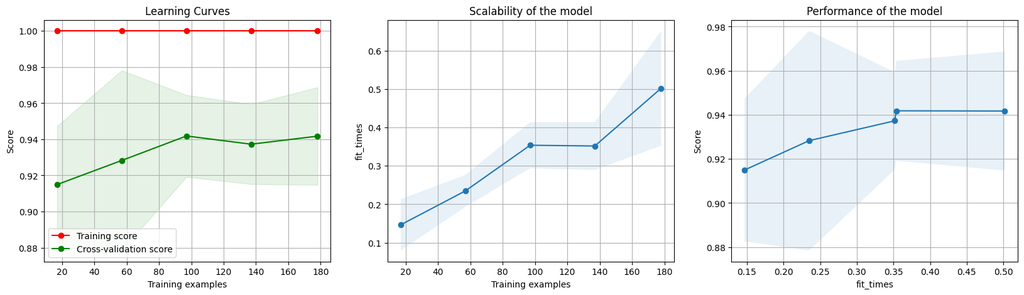

```python
# plot learning curces
plot_learning_curve(best_classifier_3, 'Learning Curves',
                    X_train_final, y_train, n_jobs=-1)
```

```python
# Final Pipeline
def final_pipeline(text):
    X_features, feature_names = featurizer.fit_transform(text)
    cleaned_text = X_test_cleaned_bow
    X_final = pd.concat((pd.DataFrame(cleaned_text, columns=['cleaned_text']),
                         pd.DataFrame(X_features, columns=feature_names)), axis=1)
    predictions = best_classifier_3.predict(X_final)
    return predictions
y_test_pred = final_pipeline(X_test)
```

```python
print('\nTest set classification report:\n\n',
      metrics.classification_report(y_test, y_test_pred))
```

```
Test set classification report:

               precision    recall  f1-score   support

           0       0.98      1.00      0.99        49
           1       1.00      0.86      0.92         7

    accuracy                           0.98        56
   macro avg       0.99      0.93      0.96        56
weighted avg       0.98      0.98      0.98        56
```